# Project 1–Vectors, Functions, and Data Frames

Seth Harrison, Baylie Higginbotham, Jamie Baxter

Thursday, September 19, 2019 @ 04:42 PM

### **Problem 1**

Create, store, and print the following vectors using functions `:`, `c`, `seq`, and/or `rep`. Use the object names indicated in CAPS.

```r
X <- c(1:10)
print(X)
```

```
 [1]  1  2  3  4  5  6  7  8  9 10
```

```r
SCORE <- seq(0, 100, by = 2)
print(SCORE)
```

```
 [1]   0   2   4   6   8  10  12  14  16  18  20  22  24  26  28  30  32
[18]  34  36  38  40  42  44  46  48  50  52  54  56  58  60  62  64  66
[35]  68  70  72  74  76  78  80  82  84  86  88  90  92  94  96  98 100
```

```r
PH <- seq(0, 14, by = .1)
print(PH)
```

```
  [1]  0.0  0.1  0.2  0.3  0.4  0.5  0.6  0.7  0.8  0.9  1.0  1.1  1.2  1.3
 [15]  1.4  1.5  1.6  1.7  1.8  1.9  2.0  2.1  2.2  2.3  2.4  2.5  2.6  2.7
 [29]  2.8  2.9  3.0  3.1  3.2  3.3  3.4  3.5  3.6  3.7  3.8  3.9  4.0  4.1
 [43]  4.2  4.3  4.4  4.5  4.6  4.7  4.8  4.9  5.0  5.1  5.2  5.3  5.4  5.5
 [57]  5.6  5.7  5.8  5.9  6.0  6.1  6.2  6.3  6.4  6.5  6.6  6.7  6.8  6.9
 [71]  7.0  7.1  7.2  7.3  7.4  7.5  7.6  7.7  7.8  7.9  8.0  8.1  8.2  8.3
 [85]  8.4  8.5  8.6  8.7  8.8  8.9  9.0  9.1  9.2  9.3  9.4  9.5  9.6  9.7
 [99]  9.8  9.9 10.0 10.1 10.2 10.3 10.4 10.5 10.6 10.7 10.8 10.9 11.0 11.1
[113] 11.2 11.3 11.4 11.5 11.6 11.7 11.8 11.9 12.0 12.1 12.2 12.3 12.4 12.5
[127] 12.6 12.7 12.8 12.9 13.0 13.1 13.2 13.3 13.4 13.5 13.6 13.7 13.8 13.9
[141] 14.0
```

```r
PLAY <- c("rock", "scissors", "paper", "lizard", "Spock")
print(PLAY)
```

```
[1] "rock"     "scissors" "paper"    "lizard"   "Spock"
```

```r
CLOCK <- seq(60, 1, by = -1)
print(CLOCK)
```

```
 [1] 60 59 58 57 56 55 54 53 52 51 50 49 48 47 46 45 44 43 42 41 40 39 38
[24] 37 36 35 34 33 32 31 30 29 28 27 26 25 24 23 22 21 20 19 18 17 16 15
[47] 14 13 12 11 10  9  8  7  6  5  4  3  2  1
```

```r
SONG <- rep(c("I get knocked down", "But I get up again", "You're never gonna keep me down"), 2)
print(SONG)
```

```
[1] "I get knocked down"              "But I get up again"
[3] "You're never gonna keep me down" "I get knocked down"
[5] "But I get up again"              "You're never gonna keep me down"
```

```r
BLOOD <- c(rep("A", 40), rep("B", 11), rep("AB", 4), rep("O", 45))
print(BLOOD)
```

```
  [1] "A"  "A"  "A"  "A"  "A"  "A"  "A"  "A"  "A"  "A"  "A"  "A"  "A"  "A"
 [15] "A"  "A"  "A"  "A"  "A"  "A"  "A"  "A"  "A"  "A"  "A"  "A"  "A"  "A"
 [29] "A"  "A"  "A"  "A"  "A"  "A"  "A"  "A"  "A"  "A"  "A"  "A"  "B"  "B"
 [43] "B"  "B"  "B"  "B"  "B"  "B"  "B"  "B"  "B"  "AB" "AB" "AB" "AB" "O"
 [57] "O"  "O"  "O"  "O"  "O"  "O"  "O"  "O"  "O"  "O"  "O"  "O"  "O"  "O"
 [71] "O"  "O"  "O"  "O"  "O"  "O"  "O"  "O"  "O"  "O"  "O"  "O"  "O"  "O"
 [85] "O"  "O"  "O"  "O"  "O"  "O"  "O"  "O"  "O"  "O"  "O"  "O"  "O"  "O"
 [99] "O"  "O"
```

### **Problem 2**

Write a `for` loop to create an integer vector that contains the first 10 numbers in the [Fibonacci sequence](https://www.mathsisfun.com/numbers/fibonacci-sequence.html).

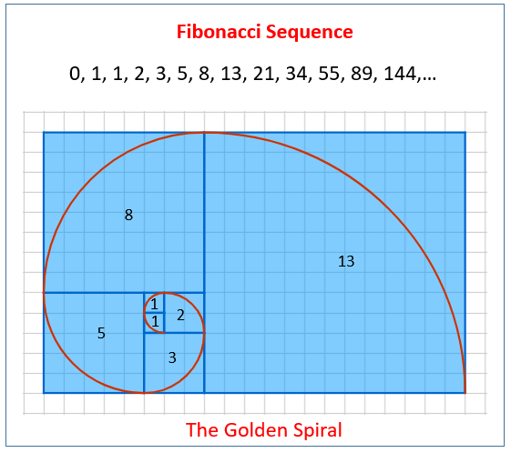

- Use the `numeric` function to create a vector of zeroes called FIB in which to store your loop results.
- Set the second element of FIB to one.
- Use a loop to calculate the remaining 8 elements (i.e., elements 3 through 10) and insert them in FIB.
- Store and print FIB when it is finished.

If you don’t get the correct sequence of 10 numbers, check your work!

```r
FIB <- numeric(length = 10)
FIB[2] <- 1
for (i in 3:10) {
  FIB[i] <- FIB[i - 2] + FIB[i - 1]
}
FIB
```

```
 [1]  0  1  1  2  3  5  8 13 21 34
```

### **Problem 3**

Adapt the code you wrote in Problem 2 as the basis for a function that will generate the first **n** digits of the Fibonacci sequence, given a user-input value of n. You should be able to save the function output as an object using the assignment arrow `<-` (for example, `outputvector <- FIBfunction(inputvalue)`). Once you have defined your function, use it with n = 100, save the vector containing the generated sequence, and print it out.

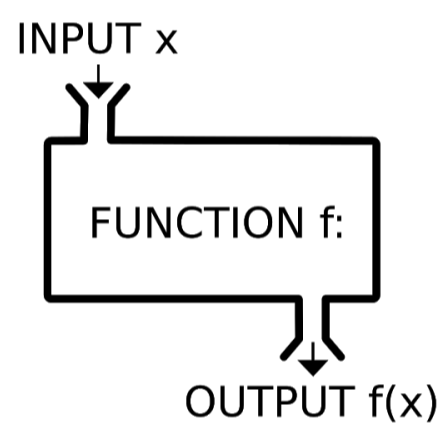

```r
FIBfunc <- function(n){
  FIB <- numeric(length = n)
  FIB[1] <- 0
  FIB[2] <- 1
  for (i in 1:(n - 2)) {
    FIB[i + 2] <- FIB[i] + FIB[i + 1]
  }
  return(FIB)
}
FIBfunc(100)
```

```
  [1] 0.000000e+00 1.000000e+00 1.000000e+00 2.000000e+00 3.000000e+00
  [6] 5.000000e+00 8.000000e+00 1.300000e+01 2.100000e+01 3.400000e+01
 [11] 5.500000e+01 8.900000e+01 1.440000e+02 2.330000e+02 3.770000e+02
 [16] 6.100000e+02 9.870000e+02 1.597000e+03 2.584000e+03 4.181000e+03
 [21] 6.765000e+03 1.094600e+04 1.771100e+04 2.865700e+04 4.636800e+04
 [26] 7.502500e+04 1.213930e+05 1.964180e+05 3.178110e+05 5.142290e+05
 [31] 8.320400e+05 1.346269e+06 2.178309e+06 3.524578e+06 5.702887e+06
 [36] 9.227465e+06 1.493035e+07 2.415782e+07 3.908817e+07 6.324599e+07
 [41] 1.023342e+08 1.655801e+08 2.679143e+08 4.334944e+08 7.014087e+08
 [46] 1.134903e+09 1.836312e+09 2.971215e+09 4.807527e+09 7.778742e+09
 [51] 1.258627e+10 2.036501e+10 3.295128e+10 5.331629e+10 8.626757e+10
 [56] 1.395839e+11 2.258514e+11 3.654353e+11 5.912867e+11 9.567220e+11
 [61] 1.548009e+12 2.504731e+12 4.052740e+12 6.557470e+12 1.061021e+13
 [66] 1.716768e+13 2.777789e+13 4.494557e+13 7.272346e+13 1.176690e+14
 [71] 1.903925e+14 3.080615e+14 4.984540e+14 8.065155e+14 1.304970e+15
 [76] 2.111485e+15 3.416455e+15 5.527940e+15 8.944394e+15 1.447233e+16
 [81] 2.341673e+16 3.788906e+16 6.130579e+16 9.919485e+16 1.605006e+17
 [86] 2.596955e+17 4.201961e+17 6.798916e+17 1.100088e+18 1.779979e+18
 [91] 2.880067e+18 4.660047e+18 7.540114e+18 1.220016e+19 1.974027e+19
 [96] 3.194043e+19 5.168071e+19 8.362114e+19 1.353019e+20 2.189230e+20
```

**Bonus:** Can you use `paste` and/or `sprintf` to “dress up” the `print` output of your vector?

### **Problem 4**

Suppose we want to simulate a game of [Rock, Paper, Scissors, Lizard, Spock](http://www.samkass.com/theories/RPSSL.html). Write a `repeat` loop using the `sample` function to represent a player’s choice of what to play on each turn. Sample from a vector like the one you created in Problem 1, assuming that all options are equally likely, and `break` the loop when Spock is first played. Print out the results of each play as the loop is running and the number of the turn on which Spock occurred at the end. (Note: There is roughly a 90% chance that number of turns will be 10 or fewer.)

[figure not shown]

**Bonus:** Can you adapt your code for a situation where the five options are not equally likely?

```r
PLAY <- c("rock", "scissors", "paper", "lizard", "Spock")
counter <- 1

repeat {
  p <- sample(PLAY, 1)
  print(p)
  if (p == "Spock") break
  counter <- counter +  1
}
```

```
[1] "Spock"
```

```r
sprintf("Spock was played on turn %s", counter)
```

```
[1] "Spock was played on turn 1"
```

### **Problem 5**

Create a dataframe containing the information in the `Project1ClassList.xlsx` spreadsheet. Later in the course you will learn to read the data into R from a `.csv` or `.xlsx` file, but for now, create a vector for each column and use the `data.frame` function to turn them into a data frame like you did in Chapter 5 of the [Introduction to R](https://www.datacamp.com/courses/free-introduction-to-r) course in DataCamp. Use `str`, `head`, and `tail` to show the structure and contents of your data frame.

```r
Name <- c(
"Atwell, Kaleb L.",
"Bass, Nicholas W.",
"Baxter, Jamie A.",
"Baxter, Madelyn M.",
"Carter, Nicholas A.",
"Daniels, Samantha B.",
"Fennell, Charles T.",
"Goodman, Madeline M.",
"Harrison, Seth W.",
"Haylett, Elise C.",
"Higginbotham, Baylie",
"Lee, Sebastien J.",
"McCook, Mary E.",
"McCrimmon, Kyera K.",
"Miranda-Hernandez, Daniela P.",
"Nilsson, Connor S.",
"Renko, Anna F.",
"Rodriguez Guzman, Bianca D.",
"Smith, Joel S.",
"Stansberry, Amanda L.",
"Tosto, Christopher H.",
"Tyndall, Matthew B.",
"Ugboro, Hope U.",
"Watkins, Alyssa M.",
"White, Joseph D.")
preferredName <- c(
"",
"Nick",
"Jamie",
"Madelyn",
"Alex",
"Sam",
"",
"Maddy",
"Seth",
"",
"",
"Sebastien",
"Maribeth",
"Kyera",
"Danni",
"Connor",
"",
"",
"",
"",
"Chris",
"",
"",
"",
"Daniel"
)
email <- c(
"atwellkl1@appstate.edu",
"bassnw@appstate.edu",
"baxterja@appstate.edu",
"baxtermm@appstate.edu",
"carterna3@appstate.edu",
"danielssb@appstate.edu",
"fennellct@appstate.edu",
"goodmanmm@appstate.edu",
"harrisonsw@appstate.edu",
"haylettec@appstate.edu",
"higginbothamb@appstate.edu",
"leesj3@appstate.edu",
"mccookme@appstate.edu",
"mccrimmonkk@appstate.edu",
"mirandahernandedp@appstate.edu",
"nilssoncs@appstate.edu",
"renkoaf@appstate.edu",
"rodriguezguzmanbd@appstate.edu",
"smithjs5@appstate.edu",
"stansberryal@appstate.edu",
"tostoch@appstate.edu",
"tyndallmb@appstate.edu",
"ugborohu@appstate.edu",
"watkinsam1@appstate.edu",
"whitejd5@appstate.edu"
)
class <- c(
"Senior",
"Junior",
"Junior",
"Sophomore",
"Senior",
"Senior",
"Senior",
"Senior",
"Junior",
"Senior",
"Junior",
"Junior",
"Senior",
"Junior",
"Senior",
"Junior",
"Junior",
"Sophomore",
"Senior",
"Junior",
"Senior",
"Junior",
"Senior",
"Senior",
"Sophomore"
)
college <- c(
"CB",
"GC",
"AS",
"AS",
"AS",
"AS",
"AS",
"AS",
"AS",
"AS",
"GC",
"AS",
"AS",
"AS",
"AS",
"AS",
"AS",
"GC",
"AS",
"AS",
"AS",
"CB",
"AS",
"AS",
"GC"
)
dataFrame <- data.frame(Name, preferredName, email, class, college)
str(dataFrame)
```

```
'data.frame':   25 obs. of  5 variables:
 $ Name         : Factor w/ 25 levels "Atwell, Kaleb L.",..: 1 2 3 4 5 6 7 8 9 10 ...
 $ preferredName: Factor w/ 15 levels "","Alex","Chris",..: 1 12 7 10 2 13 1 9 15 1 ...
 $ email        : Factor w/ 25 levels "atwellkl1@appstate.edu",..: 1 2 3 4 5 6 7 8 9 10 ...
 $ class        : Factor w/ 3 levels "Junior","Senior",..: 2 1 1 3 2 2 2 2 1 2 ...
 $ college      : Factor w/ 3 levels "AS","CB","GC": 2 3 1 1 1 1 1 1 1 1 ...
```

```r
head(dataFrame)
```

```
                  Name preferredName                  email     class
1     Atwell, Kaleb L.               atwellkl1@appstate.edu    Senior
2    Bass, Nicholas W.          Nick    bassnw@appstate.edu    Junior
3     Baxter, Jamie A.         Jamie  baxterja@appstate.edu    Junior
4   Baxter, Madelyn M.       Madelyn  baxtermm@appstate.edu Sophomore
5  Carter, Nicholas A.          Alex carterna3@appstate.edu    Senior
6 Daniels, Samantha B.           Sam danielssb@appstate.edu    Senior
  college
1      CB
2      GC
3      AS
4      AS
5      AS
6      AS
```

```r
tail(dataFrame)
```

```
                    Name preferredName                     email     class
20 Stansberry, Amanda L.               stansberryal@appstate.edu    Junior
21 Tosto, Christopher H.         Chris      tostoch@appstate.edu    Senior
22   Tyndall, Matthew B.                  tyndallmb@appstate.edu    Junior
23       Ugboro, Hope U.                   ugborohu@appstate.edu    Senior
24    Watkins, Alyssa M.                 watkinsam1@appstate.edu    Senior
25      White, Joseph D.        Daniel     whitejd5@appstate.edu Sophomore
   college
20      AS
21      AS
22      CB
23      AS
24      AS
25      GC
```